# Proyecto Ciencia de Datos 2022-2023

Daniel Solano Florián

19/03/2023

# Competencia de roedores por área de distribución en Silwood Park

## Introducción

En el bosque de Silwood Park, en el sur de Inglaterra, se llevó a cabo un estudio en roedores que recolectó datos sobre tres especies: *Apodemus sylvaticus*, *Apodemus flavicollis* y *Myodes glareolus* (*Clethrionomys glareolus*). Anteriormente, los individuos fueron marcados con un PIT tag que permitió registrar, mediante data loggers, la fecha de sus visitas a cajas localizadas en coordenadas específicas dentro del área de estudio.

```r
library(ggplot2)
library(ggthemes)
```

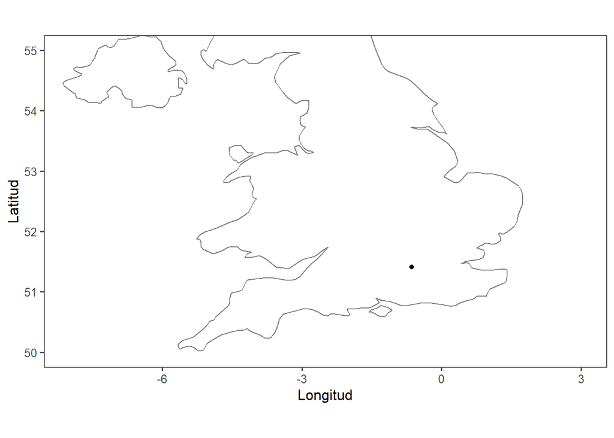

```r
coords.SP <- data.frame(
  lon = -0.641,
  lat = 51.4086
)
ggplot () +
  borders(regions = "UK") +
  geom_point(data = coords.SP, aes(x = lon, y = lat)) +
  coord_fixed(xlim=c(-8,3), ylim=c(50,55), ratio = 1.3) +
  xlab("Longitud")+
  ylab("Latitud")+
  theme_few()
```

Estas tres especies, englobadas en la superfamilia Muroidea, presentan ciertas diferencias respecto a su distribución: mientras *M. glareolus* y *A. flavicollis* prefieren áreas boscosas densas, *A. sylvaticus* se distribuye ampliamente; sin embargo, en lo que a su morfología se refiere, son muy similares.

### Objetivos

La presencia de poblaciones de las tres especies de roedores en Silwood Park plantea la posibilidad de que exista exclusión entre ellas. Para evaluar esta hipótesis, es necesario no solo considerar su distribución absoluta, sino también las variaciones en su distribución a lo largo de los meses: la exclusión puede ser espacial y/o temporal. Por lo tanto, el objetivo de este proyecto es calcular y verificar el grado de solapamiento entre las áreas de distribución de las especies. Además, se examinará si existe exclusión espacial y temporal entre los sexos, independientemente de la especie.

## Descripción de los datos

### Origen

Los datos fueron facilitados por el profesor Aurelio Malo Valenzuela (aurelio.malo@uah.es) del Departamento de Ciencias de la Vida, sobre su estudio de roedores para el Imperial College of London.

```r
datos1 <- read.csv("~/GitHub/DataScienceUAH/Students 2023/Daniel Solano/data/dataAurelio.csv",
         sep=";")
```

### Variables seleccionadas

De los datos proporcionados se seleccionaron las variables correspondientes a coordenadas espaciales, especie, sexo, tiempo (día, mes y año) y visita.

```r
datos.clean <- subset(datos1, select=c("x.coord.1m", "y.coord.1m", "Species", "Sex", "day", "month", "year", "visit"))

datos.clean.agg <-
  aggregate(cbind(visit) ~ x.coord.1m +y.coord.1m+Species+Sex+year+month, data = datos.clean, sum)

head(datos.clean.agg)
```

```
##   x.coord.1m y.coord.1m Species Sex year month visit
## 1         55          7      AS   F   11     1     1
## 2         37         20      AS   F   11     1     1
## 3         92         26      AS   F   11     1     1
## 4        174         31      AS   F   11     1     1
## 5        115         35      AS   F   11     1     1
## 6        138         35      AS   F   11     1     1
```

## Tratamiento de datos

### Paquetes

```r
#library(ggplot2)
#library(ggthemes)
library(easyclimate)
library(gridExtra)
library(raster)
library(reshape2)
library(sf)
library(sp)
library(tidyverse)
```

### Ejemplo de lo que se quiere obtener

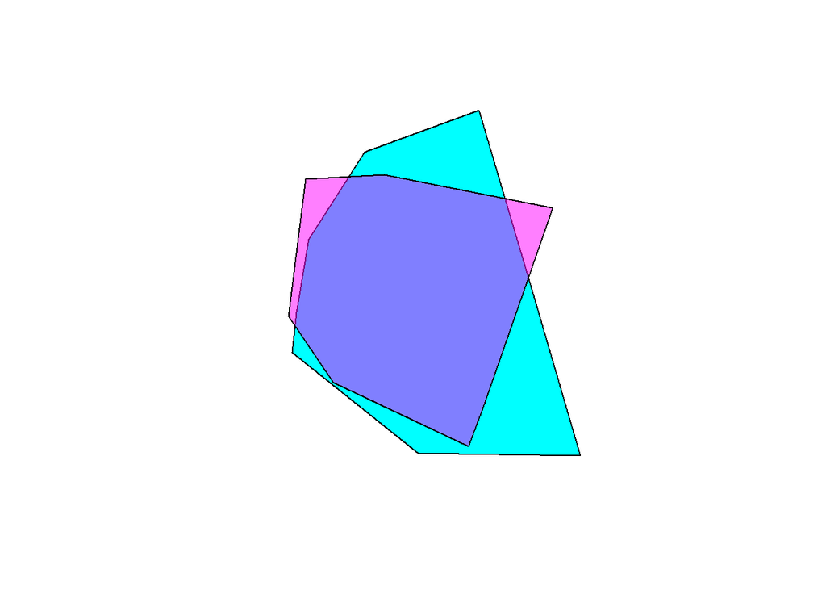

```r
#Poligono 1
df1 <- data.frame(x = rnorm(50), y = rnorm(50))
invisible(df1[order(df1[,"x"], df1[,"y"]),])

rango.df1 <- chull(df1[,c("x", "y")])
rango.df1 <- c(rango.df1, rango.df1[1])

coords.df1 <- as.data.frame(df1[rango.df1,c("x", "y")])

pdf1 <- Polygon(coords.df1)
psdf1 <- Polygons(list(pdf1),1)
spsdf1 <- SpatialPolygons(list(psdf1))
convex.df1 <- st_as_sf(spsdf1, coords = c("x", "y"), crs = 4326)
convex.df1 = st_make_valid(convex.df1)

#Poligono 2
df2 <- data.frame(x = rnorm(50), y = rnorm(50))
invisible(df2[order(df1[,"x"], df1[,"y"]),])

rango.df2 <- chull(df2[,c("x", "y")])
rango.df2 <- c(rango.df2, rango.df2[1])

coords.df2 <- as.data.frame(df2[rango.df2,c("x", "y")])

pdf2 <- Polygon(coords.df2)
psdf2 <- Polygons(list(pdf2),1)
spsdf2 <- SpatialPolygons(list(psdf2))
convex.df2 <- st_as_sf(spsdf2, coords = c("x", "y"), crs = 4326)
convex.df2 = st_make_valid(convex.df2)


plot(convex.df1, col = "cyan")
plot(convex.df2, add = T, col = alpha("magenta", 0.5))
```

En esta figura se puede ver una zona de solapamiento entre dos polígonos; se necesita crear una figura como esta para cada mes de los 4 años de los que se tienen datos. Para ello, hará falta utilizar un loop que se encargue de repetir un mismo procedimiento para cada mes.

### Antes del loop

Antes de comenzar el loop se necesita saber cuáles son todos los posibles emparejamientos que puede haber según especie y sexo.

#### Especie y Sexo

```r
#Creamos un data.frame que comprenda todos los posibles emparejamientos según especie y sexo
subsets = expand.grid(Species1 = c("AS","AF","CG"),
                      Sex1 = c("F", "M"),
                      Species2 = c("AS","AF","CG"),
                      Sex2 = c("F", "M")
)

subsets = subsets[-c(1,8,15,22,29,36),]
subsets$Species1 = as.character(subsets$Species1)
subsets$Species2 = as.character(subsets$Species2)
subsets$Sex1 = as.character(subsets$Sex1)
subsets$Sex2 = as.character(subsets$Sex2)

#Añadimos un índice que represente cada posibilidad en una sola columna
subsets$indice <- apply(subsets, 1, function(x) {
  sort.i <- sort(x)
  paste0(sort.i[1], sort.i[2], sort.i[3], sort.i[4])
})

#Vemos qué emparejamientos se repiten y los eliminamos
indicequitar = which (duplicated(subsets$indice))

subsets = subsets[-indicequitar,]

head(subsets)
```

```
##   Species1 Sex1 Species2 Sex2 indice
## 2       AF    F       AS    F AFASFF
## 3       CG    F       AS    F ASCGFF
## 4       AS    M       AS    F ASASFM
## 5       AF    M       AS    F AFASFM
## 6       CG    M       AS    F ASCGFM
## 9       CG    F       AF    F AFCGFF
```

#### Año y mes

```r
#Delimitamos de dónde hasta donde tiene que correr el futuro loop
nyear = 10:13
nmonth = 1:12
nsubs = nrow(subsets)
```

Además, hay que crear un objeto donde se introduzcan los datos del loop una vez calculados.

```r
#Establecemos los array donde introduciremos los datos calculados por el loop
tabla.solapamientos = array(NA, dim = c(12,5,4,12))
tabla.especies.area = array(NA, dim = c(12,2,4,12))
```

### Loop

```r
#Establecemos el loop

for (i in nyear) {

  #Creamos un subset por cada año
  datos.clean.agg.i = subset (datos.clean.agg, year == i)
  year.i = which(nyear==i)


  for (j in nmonth) {

    #Dentro de cada año creamos subsets para cada mes
    datos.clean.agg.i.j = subset(datos.clean.agg.i, month == j)



    if(nrow(datos.clean.agg.i.j)>0){
      for (k in 1:nsubs) {#Comenzamos un loop para calcular cada caso


        #print(paste(i,j,k))#Para ver cómo se calcula cada caso de uno en uno

        #Primero eliminando casos que dan errores
        if(paste(i,j,k) != "11 3 26" &
           paste(i,j,k) != "11 10 9" &
           paste(i,j,k) != "11 10 7"){


          #Creamos dos subsets, cada uno con uno de los integrantes de cada emparejamiento
          datos.clean.agg.i.j.k.1 = subset(datos.clean.agg.i.j, Species == subsets[k,1] & Sex == subsets[k,2])
          datos.clean.agg.i.j.k.2 = subset(datos.clean.agg.i.j, Species == subsets[k,3] & Sex == subsets[k,4])

          #Para confirmar que ambos subsets contienen datos
          if(nrow(datos.clean.agg.i.j.k.1) > 0 & nrow(datos.clean.agg.i.j.k.2) > 0){

            #Se le pone un orden a las coordenadas
            datos.clean.agg.i.j.k.1[order(datos.clean.agg.i.j.k.1[,"x.coord.1m"],
                                          datos.clean.agg.i.j.k.1[,"y.coord.1m"]),]

            #Para poder crear un objeto que contenga las coordenadas exteriores de cada integrante del emparejamiento
            rango.k.1.ch <- chull(datos.clean.agg.i.j.k.1[,c("x.coord.1m", "y.coord.1m")])
            rango.k.1.ch <- c(rango.k.1.ch, rango.k.1.ch[1])


            datos.clean.agg.i.j.k.2[order(datos.clean.agg.i.j.k.2[,"x.coord.1m"],
                                          datos.clean.agg.i.j.k.2[,"y.coord.1m"]),]

            rango.k.2.ch <- chull(datos.clean.agg.i.j.k.2[,c("x.coord.1m", "y.coord.1m")])
            rango.k.2.ch <- c(rango.k.1.ch, rango.k.2.ch[1])

            #Creamos un sf object
            coords.k.1 <- as.data.frame(datos.clean.agg.i.j.k.1[rango.k.1.ch,c("x.coord.1m", "y.coord.1m")])
            coords.k.1 <- subset(coords.k.1,!is.na(x.coord.1m))
            p.k.1 = Polygon(coords.k.1)
            ps.k.1 = Polygons(list(p.k.1),1)
            sps.k.1 = SpatialPolygons(list(ps.k.1))
            convex.k.1 <- st_as_sf(sps.k.1, coords = c("x.coord.1m", "y.coord.1m"), crs = 4326)

            coords.k.2 <- as.data.frame(datos.clean.agg.i.j.k.2[rango.k.2.ch,c("x.coord.1m", "y.coord.1m")])
            coords.k.2 <- subset(coords.k.2,!is.na(x.coord.1m))
            p.k.2 = Polygon(coords.k.2)
            ps.k.2 = Polygons(list(p.k.2),1)
            sps.k.2 = SpatialPolygons(list(ps.k.2))
            convex.k.2 <- st_as_sf(sps.k.2, coords = c("x.coord.1m", "y.coord.1m"), crs = 4326)


            if (st_is_valid(convex.k.1) == FALSE | st_is_valid(convex.k.2) == FALSE) {

              #En caso de que el objeto de error, lo volvemos válido
              convex.k.1 = st_make_valid(convex.k.1)
              convex.k.2 = st_make_valid(convex.k.2)

            }

            #Creamos un objeto que represente el área de solapamiento entre los dos integrantes del emparejamiento
            k.1k.2_intersect <- st_intersection (convex.k.1, convex.k.2)

            #Calculamos el valor de las áreas de cada integrante del emparejamiento
            area.k1 = st_area(convex.k.1)
            area.k2 = st_area(convex.k.2)

            #Incorporamos los datos a los array que hemos creado antes
            if (length(k.1k.2_intersect$geometry) == 0) {#En caso de que no haya solapamiento

              tabla.solapamientos[j,1,year.i,k] = area.k1.k2 = 0
              tabla.solapamientos[j,2,year.i,k] = area.k1.k2.total = (area.k1 - area.k1.k2) + (area.k1 - area.k1.k2) + area.k1.k2
              tabla.solapamientos[j,3,year.i,k] = prop.solapamiento.k1.k2 = area.k1.k2/area.k1.k2.total*100
              tabla.solapamientos[j,4,year.i,k] = prop.solapamiento.k = area.k1.k2/area.k1*100
              tabla.solapamientos[j,5,year.i,k] = prop.solapamiento.k = area.k1.k2/area.k2*100

              tabla.especies.area[j,1,year.i,k] = area.k1
              tabla.especies.area[j,2,year.i,k] = area.k2

            } else {#En caso de que sí haya solapamiento

              tabla.solapamientos[j,1,year.i,k] = area.k1.k2 = st_area(k.1k.2_intersect)
              tabla.solapamientos[j,2,year.i,k] = area.k1.k2.total = (area.k1 - area.k1.k2) + (area.k1 - area.k1.k2) + area.k1.k2
              tabla.solapamientos[j,3,year.i,k] = prop.solapamiento.k1.k2 = area.k1.k2/area.k1.k2.total*100
              tabla.solapamientos[j,4,year.i,k] = prop.solapamiento.k = area.k1.k2/area.k1*100
              tabla.solapamientos[j,5,year.i,k] = prop.solapamiento.k = area.k1.k2/area.k2*100

              tabla.especies.area[j,1,year.i,k] = area.k1
              tabla.especies.area[j,2,year.i,k] = area.k2
            }

          }
        }
      }}
  }
}
```

### Después del loop

Tras el loop, los datos calculados se reparten en dos tablas, una que recoge los valores de los solapamientos (Tabla.solapamientos.final) y otra que únicamente contiene los valores de las áreas de distribución individuales (Tabla.especies.final).

```r
#Lo convertimos en un data.frame
tabla.solapamientos.final <- melt(tabla.solapamientos)

head(tabla.solapamientos.final)
```

```
##   Var1 Var2 Var3 Var4 value
## 1    1    1    1    1    NA
## 2    2    1    1    1    NA
## 3    3    1    1    1    NA
## 4    4    1    1    1    NA
## 5    5    1    1    1    NA
## 6    6    1    1    1    NA
```

```r
##Limpieza del array 'tabla.solapamientos'

tabla.solapamientos.final = tabla.solapamientos.final[!is.na(tabla.solapamientos.final$value),]#Eliminamos los NA

variables = c("months", "formula", "year", "species.int", "value")#Le damos nombre a las variables
colnames(tabla.solapamientos.final) <- variables #Y se los añadimos al data.frame

#Cambiamos el nombre de los valores en las variables 'formula', 'year' y 'species.int'
tabla.solapamientos.final$formula = ifelse(tabla.solapamientos.final$formula == 1,  "intersect.area",
                                    ifelse(tabla.solapamientos.final$formula == 2,  "total.area",
                                    ifelse(tabla.solapamientos.final$formula == 3,  "%overlap",
                                    ifelse(tabla.solapamientos.final$formula == 4,  "%overlap.esp1",
                                    ifelse(tabla.solapamientos.final$formula == 5,  "%overlap.esp2", NA
                                    )))))

tabla.solapamientos.final$year = ifelse(tabla.solapamientos.final$year == 1,  "10",
                                 ifelse(tabla.solapamientos.final$year == 2,  "11",
                                 ifelse(tabla.solapamientos.final$year == 3,  "12",
                                 ifelse(tabla.solapamientos.final$year == 4,  "13", NA
                                 ))))

tabla.solapamientos.final$species.int = ifelse(tabla.solapamientos.final$species.int == 1,  "AF.AS/F.F",
                                        ifelse(tabla.solapamientos.final$species.int == 2,  "CG.AS/F.F",
                                        ifelse(tabla.solapamientos.final$species.int == 3,  "AS.AS/M.F",
                                        ifelse(tabla.solapamientos.final$species.int == 4,  "AF.AS/M.F",
                                        ifelse(tabla.solapamientos.final$species.int == 5,  "CG.AS/M.F",
                                        ifelse(tabla.solapamientos.final$species.int == 6,  "CG.AF/F.F",
                                        ifelse(tabla.solapamientos.final$species.int == 7,  "AF.AF/M.F",
                                        ifelse(tabla.solapamientos.final$species.int == 8,  "CG.AF/M.F",
                                        ifelse(tabla.solapamientos.final$species.int == 9,  "CG.CG/M.F",
                                        ifelse(tabla.solapamientos.final$species.int == 10, "AF.AS/M.M",
                                        ifelse(tabla.solapamientos.final$species.int == 11, "CG.AS/M.M",
                                        ifelse(tabla.solapamientos.final$species.int == 12, "CG.AF/M.M", NA
                                        ))))))))))))

#Separamos la variable 'species.int' en dos nuevas: 'species' y 'sex'
tabla.solapamientos.final <- tabla.solapamientos.final |>
  separate(col = species.int, into = c("species", "sex"), sep = "\\/", remove = F)

head(tabla.solapamientos.final)
```

```
##    months        formula year species.int species sex       value
## 10     10 intersect.area   10   AF.AS/F.F   AF.AS F.F     0.00000
## 11     11 intersect.area   10   AF.AS/F.F   AF.AS F.F    97.23189
## 12     12 intersect.area   10   AF.AS/F.F   AF.AS F.F     0.00000
## 22     10     total.area   10   AF.AS/F.F   AF.AS F.F  1363.00000
## 23     11     total.area   10   AF.AS/F.F   AF.AS F.F 16316.76811
## 24     12     total.area   10   AF.AS/F.F   AF.AS F.F     0.00000
```

```r
##Limpieza del array 'tabla.especies.area'

tabla.especies.final <- melt(tabla.especies.area)

tabla.especies.final = tabla.especies.final[!is.na(tabla.especies.final$value),]

colnames(tabla.especies.final) <- variables

tabla.especies.final$formula = ifelse(tabla.especies.final$formula == 1,  "species1.area",
                               ifelse(tabla.especies.final$formula == 2,  "species2.area", NA
                               ))

tabla.especies.final$year = ifelse(tabla.especies.final$year == 1,  "10",
                            ifelse(tabla.especies.final$year == 2,  "11",
                            ifelse(tabla.especies.final$year == 3,  "12",
                            ifelse(tabla.especies.final$year == 4,  "13", NA
                            ))))

tabla.especies.final$species.int = ifelse(tabla.especies.final$species.int == 1,  "AF.AS/F.F",
                                   ifelse(tabla.especies.final$species.int == 2,  "CG.AS/F.F",
                                   ifelse(tabla.especies.final$species.int == 3,  "AS.AS/M.F",
                                   ifelse(tabla.especies.final$species.int == 4,  "AF.AS/M.F",
                                   ifelse(tabla.especies.final$species.int == 5,  "CG.AS/M.F",
                                   ifelse(tabla.especies.final$species.int == 6,  "CG.AF/F.F",
                                   ifelse(tabla.especies.final$species.int == 7,  "AF.AF/M.F",
                                   ifelse(tabla.especies.final$species.int == 8,  "CG.AF/M.F",
                                   ifelse(tabla.especies.final$species.int == 9,  "CG.CG/M.F",
                                   ifelse(tabla.especies.final$species.int == 10, "AF.AS/M.M",
                                   ifelse(tabla.especies.final$species.int == 11, "CG.AS/M.M",
                                   ifelse(tabla.especies.final$species.int == 12, "CG.AF/M.M", NA
                                   ))))))))))))

tabla.especies.final <- tabla.especies.final |>
  separate(col = species.int, into = c("species", "sex"), sep = "\\/", remove = F)

#Separamos tabla.especies.final en 2 data.frame según el área calculada
tabla.especies1.final <- subset(tabla.especies.final, tabla.especies.final$formula == "species1.area")
tabla.especies2.final <- subset(tabla.especies.final, tabla.especies.final$formula == "species2.area")

#Nos quedamos sólo con la primera de las especies del emparejamiento
tabla.especies1.final <- tabla.especies1.final %>%
  mutate(species = sub("\\..*", "", species))

#Hacemos lo mismo con la segunda especie
tabla.especies2.final <- tabla.especies2.final %>%
  mutate(species = sub(".*\\.", "", species))

#Unimos las tablas de nuevo en una
tabla.especies.final <- merge(x = tabla.especies1.final, y = tabla.especies2.final, all = T)

head(tabla.especies.final)
```

```
##   months       formula year species.int species sex value
## 1      1 species1.area   11   AF.AS/M.F      AF M.F  1249
## 2      1 species1.area   11   AF.AS/M.M      AF M.M  1249
## 3      1 species1.area   11   AS.AS/M.F      AS M.F 11452
## 4      1 species1.area   12   AF.AF/M.F      AF M.F  4477
## 5      1 species1.area   12   AF.AS/F.F      AF F.F  3797
## 6      1 species1.area   12   AF.AS/M.F      AF M.F  4477
```

## Resultados

### Área total por especie

El boxplot que se obtiene con los datos de la Tabla.especies.final muestra que a pesar de ser la especie con valores de distribución más altos, *A.* *sylvaticus* presenta la menor mediana de todos, seguido muy de cerca por *A. flavicollis*.

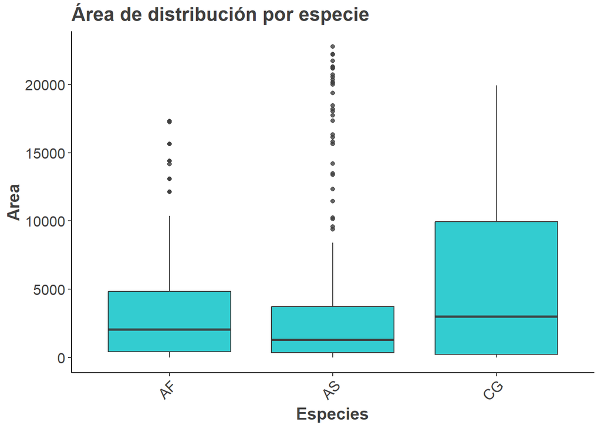

```r
ggplot(data = tabla.especies.final, aes(x = species, y = value)) +
  geom_boxplot(fill = "#00BFC4", color = "#3F3F3F", alpha = 0.8) +
  theme_bw() +
  labs(x = "Especies", y = "Area") +
  theme(
    axis.line = element_line(linewidth = 0.5),
    axis.text.x = element_text(size = 12, color = "#3F3F3F", angle = 45, hjust = 1),
    axis.text.y = element_text(size = 12, color = "#3F3F3F"),
    axis.title = element_text(size = 14, color = "#3F3F3F", face = "bold"),
    panel.grid.major = element_blank(),
    panel.grid.minor = element_blank(),
    panel.border = element_blank(),
    legend.position = "none",
    plot.title = element_text(size = 16, color = "#3F3F3F", face = "bold"),
    plot.subtitle = element_text(size = 14, color = "#3F3F3F")
  ) +
  ggtitle("Área de distribución por especie")
```

### Porcentaje de solapamiento entre especies a lo largo del tiempo

Para realizar esta gráfica primero hay que hacer un subset que sólo recoja los valores del porcentaje de solapamiento, para luego hacer otros tres subsets, uno para cada especie.

```r
per.overlap <- subset(tabla.solapamientos.final, tabla.solapamientos.final$formula == "%overlap")

per.overlap.AS <- subset(per.overlap, species %in% c("AS.AS", "AF.AS", "CG.AS"))
per.overlap.AS.agg <- per.overlap.AS %>%
  group_by(months, species) %>%
  summarize(mean_value = mean(value), .groups = "keep")


per.overlap.AF <- subset(per.overlap, species %in% c("AF.AF", "AF.AS", "CG.AF"))
per.overlap.AF.agg <- per.overlap.AF %>%
  group_by(months, species) %>%
  summarize(mean_value = mean(value), .groups = "keep")


per.overlap.CG <- subset(per.overlap, species %in% c("CG.CG", "CG.AF", "CG.AS"))
per.overlap.CG.agg <- per.overlap.CG %>%
  group_by(months, species) %>%
  summarize(mean_value = mean(value), .groups = "keep")
```

La gráfica está dividida en tres para percibir mejor la relación de cada especie consigo misma y con las demás. Por lo general existe mayor solapamiento entre grupos de la misma especie.

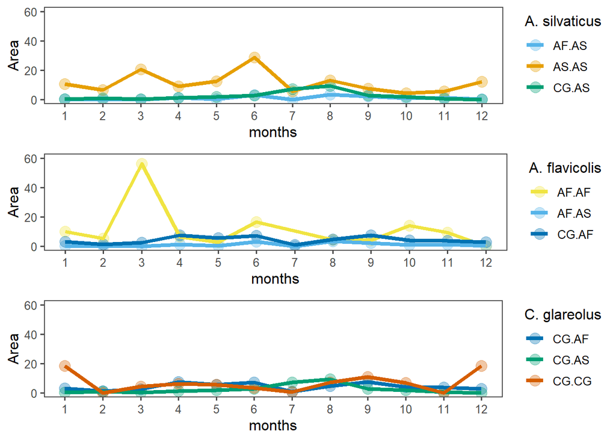

```r
color_palette <- c("#E69F00", "#56B4E9", "#009E73", "#F0E442", "#0072B2", "#D55E00")
names(color_palette) <- c("AS.AS", "AF.AS", "CG.AS", "AF.AF", "CG.AF", "CG.CG")

colores_species_line_AS <- ggplot(data = per.overlap.AS.agg, aes(x = months, y = mean_value, color = species))+
  geom_point(aes(), size = 4, alpha = 0.35)+
  geom_line(linewidth = 1.5)+
  scale_x_continuous(breaks = c(1:12), labels = c(1:12))+
  ylab("Area")+
  ylim(0, 60)+
  scale_color_manual(values = color_palette, name = "A. silvaticus")+
  theme_few()

colores_species_line_AF <- ggplot(data = per.overlap.AF.agg, aes(x = months, y = mean_value, color = species))+
  geom_point(aes(), size = 4, alpha = 0.35)+
  geom_line(linewidth = 1.5)+
  scale_x_continuous(breaks = c(1:12), labels = c(1:12))+
  ylab("Area")+
  ylim(0, 60)+
  scale_color_manual(values = color_palette, name = "A. flavicolis")+
  theme_few()

colores_species_line_CG <- ggplot(data = per.overlap.CG.agg, aes(x = months, y = mean_value, color = species))+
  geom_point(aes(), size = 4, alpha = 0.35)+
  geom_line(linewidth = 1.5)+
  scale_x_continuous(breaks = c(1:12), labels = c(1:12))+
  ylab("Area")+
  ylim(0, 60)+
  scale_color_manual(values = color_palette, name = "C. glareolus")+
  theme_few()

grid.arrange(colores_species_line_AS, colores_species_line_AF, colores_species_line_CG, nrow = 3)
```

### Diferencias en porcentaje de solapamiento según sexo

El boxplot muestra el porcentaje de solapamiento en los diferentes años, excluyendo el año 13 al sólo contener datos de los primeros meses. Se han desechado los datos entre machos y hembras de la misma especie porque puede distorsionar la gráfica, ya que el solapamiento intrasexual e intraespecífico no está reflejado tampoco (se considera la misma población).

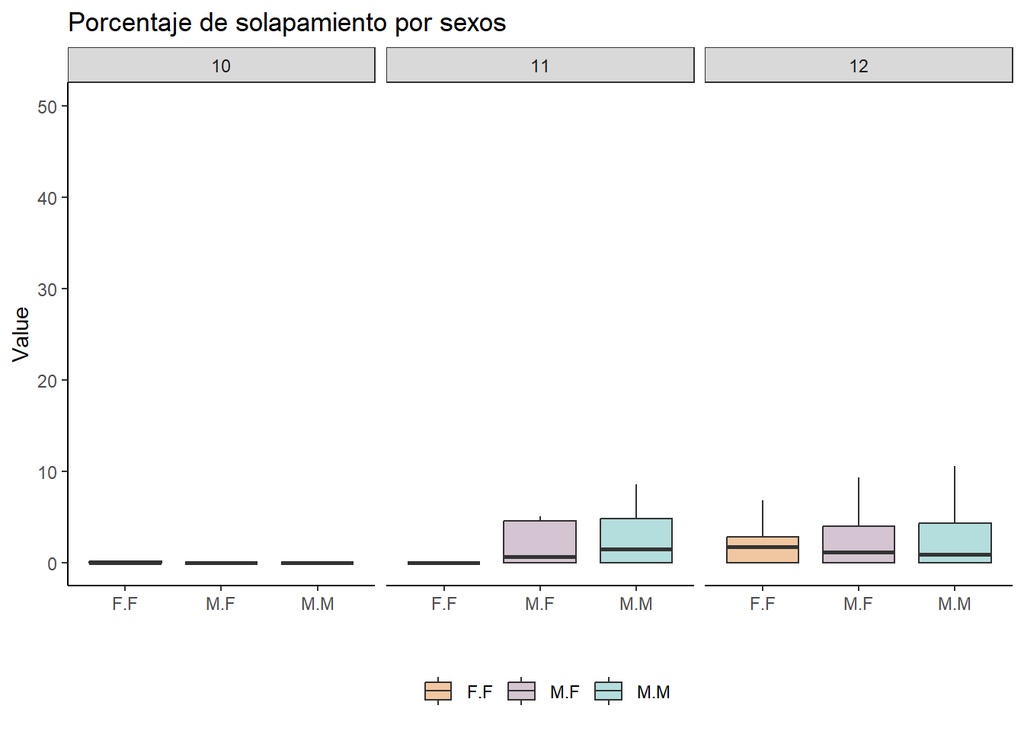

```r
per.overlap.sex <- subset(per.overlap, year %in% c("10", "11", "12"))
per.overlap.sex <- per.overlap.sex[!(per.overlap.sex$species %in% c("AS.AS", "AF.AF", "CG.CG")),]

my_palette <- c("#EDB98A", "#CBB5C5", "#A1D5D5")

ggplot(data = per.overlap.sex, aes(x = sex, y = value, fill = sex)) +
  geom_boxplot(alpha = 0.8, outlier.shape = NA) +
  facet_grid(~ year, scales = "free_x", space = "free_x") +
  scale_fill_manual(values = my_palette) +
  theme_bw() +
  theme(panel.grid = element_blank(),
        panel.border = element_blank(),
        axis.line = element_line(colour = "black"),
        legend.title = element_blank(),
        legend.position = "bottom",
        legend.box = "horizontal",
        legend.direction = "horizontal") +
  xlab("") +
  ylab("Value") +
  labs(title = "Porcentaje de solapamiento por sexos")
```

## EasyClimate

Para ver si había alguna relación entre la temperatura y el área de distribución, se descargaron datos de EasyClimate para temperaturas máxima y mínima en Silwood Park.

```r
#Tmin <- get_daily_climate(
#  coords = coords.SP,
#  climatic_var = "Tmin",
#  period = 2010:2013
#)
#Tmin <- select(Tmin, -ID_coords & -lon & -lat)
Tmin <- read.csv("~/GitHub/DataScienceUAH/Students 2023/Daniel Solano/data/Tmin_SP.csv")


#Tmax <- get_daily_climate(
#  coords = coords.SP,
#  climatic_var = "Tmax",
#  period = 2010:2013
#)
#Tmax <- select(Tmax, -ID_coords & -lon & -lat)
Tmax <- read.csv("~/GitHub/DataScienceUAH/Students 2023/Daniel Solano/data/Tmax_SP.csv")
```

Los datos de ambos data.frames son necesarios para crear un objeto nuevo con la temperatura media del área de estudio.

```r
#Calculamos la temperatura media
Tmedia <- full_join(Tmin, Tmax, by="date")
Tmedia.clean <- Tmedia |>
  separate(col = date, into = c("year", "month", "day"), sep = "\\-", remove = T)

#Limpiamos el data.frame
Tmedia.clean <- mutate(Tmedia.clean, year = as.numeric(year),
                     month = as.numeric(month),
                     day = as.numeric(day),
                     Tmedia = (Tmin + Tmax)/2)

Tmedia.clean <- dplyr::select(Tmedia.clean, -c("Tmin", "Tmax"))

Tmedia.clean.agg <- aggregate(cbind(Tmedia) ~ year + month, data = Tmedia.clean, mean)

Tmedia.clean.agg$year = ifelse(Tmedia.clean.agg$year == 2010, "10",
                        ifelse(Tmedia.clean.agg$year == 2011, "11",
                        ifelse(Tmedia.clean.agg$year == 2012, "12",
                        ifelse(Tmedia.clean.agg$year == 2013, "13", NA
                        ))))

Tmedia.clean.agg$months = Tmedia.clean.agg$month
Tmedia.clean.agg <- dplyr::select(Tmedia.clean.agg, -month)
Tmedia.clean.agg$year <- as.numeric(Tmedia.clean.agg$year)

#Creo otro data.frame que une los datos de Tmedia con los del área de distribución de las especies
Tmedia.especies <- merge(x = tabla.especies.final, y = Tmedia.clean.agg, by = c("months", "year"), all=TRUE)
Tmedia.especies <- na.omit(Tmedia.especies)
```

Con el data.frame que agrupa los datos de temperatura media y área de distribución se obtiene la siguiente gráfica de dispersión:

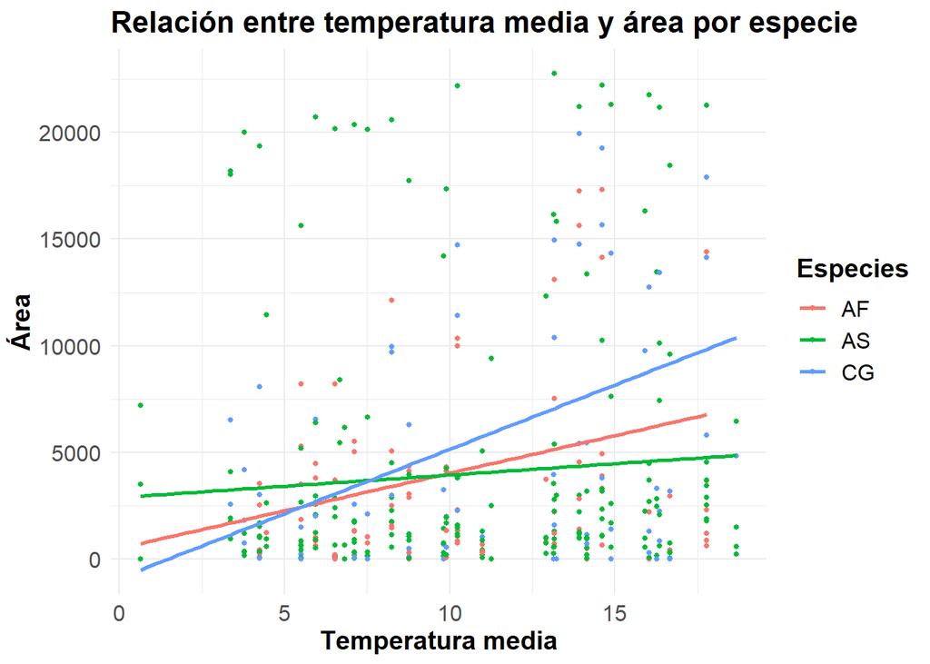

```r
ggplot(Tmedia.especies, aes(x = Tmedia, y = value, color = species)) +
  geom_point(size = 1) +
  geom_smooth(method = "lm", se = FALSE, aes(group = species)) +
  labs(x = "Temperatura media", y = "Área", color = "Especies") +
  ggtitle("Relación entre temperatura media y área por especie") +
  theme_minimal() +
  theme(axis.title = element_text(size = 14, face = "bold"),
        axis.text = element_text(size = 12),
        legend.title = element_text(size = 14, face = "bold"),
        legend.text = element_text(size = 12),
        plot.title = element_text(size = 16, face = "bold"))
```

## Discusión

El tratamiento de los datos se comenzó desde un data.frame (datos.clean.agg) que contenía muchas más observaciones para la especie *A. sylvaticus*.

```r
table(datos.clean.agg$Species)
```

```
##
##   AF   AS   CG
##  795 4933  901
```

Por lo tanto en un principio se esperaba que el área de distribución de esta especie fuese superior que las del resto. Sin embargo, en la primera gráfica mostrada, se puede ver que aunque hay valores muy altos del área de distribución de *A. sylvaticus*, son valores atípicos, mientras que los valores de los boxplot de *A. flavicollis* y *M. glareolus* son en general más altos. Cabría la posibilidad de que esto se debiese a los pocos datos que hay de estas dos especies respecto a *A. sylvaticus*:

```r
table(tabla.especies.final$species)
```

```
##
##  AF  AS  CG
## 138 217 183
```

La diferencia de observaciones entre las especies se ha reducido considerablemente, lo que puede significar que *A. sylvaticus*, aunque más numeroso, concentra sus poblaciones mucho más.

La segunda gráfica muestra el grado de solapamiento entre las especies; lo que se ve a simple vista es que hay más solapamiento entre poblaciones de la misma especie. Sin embargo este dato está sesgado, pues lo que se refleja realmente es el solapamiento entre machos y hembras. La importancia de la gráfica reside en el bajo porcentaje de solapamiento entre las especies, que no llega a alcanzar el 20%. Las gráficas 1 y 2 en conjunto reflejan una posible exclusión interespecífica, con porcentajes especialmente bajos en los meses de invierno.

Respecto a la tercera gráfica, es notable que el solapamiento en el primer año sea nulo, si bien en los otros dos años aumenta sin grandes diferencias entre los grupos.

Finalmente, la gráfica que relaciona la temperatura media con el área de distribución de las especies muestra correlación positiva, sobre todo en el caso de *M. glareolus*. Esto puede significar que la distribución de la especie esté más marcada por la temperatura que por ejemplo en el caso de *A. sylvaticus*, pero correlación no implica causalidad y podría tener que ver con otro fenómeno relacionado con el cambio de estaciones.

En definitiva, estos resultados, si bien no están apoyados por un análisis estadístico, sugieren una posible exclusión entre especies, y dan pie a futuros estudios que demuestren este hecho así como el posible efecto de otros parámetros como puede ser la temperatura.